# A2_Nguyen_Vu

Vu Nguyen

2024-05-29

Created May 29 2024 MP

# 1 install packages

```r
install.packages(c("C50", "rminer", "caret", "Rmarkdown", "tictoc", "tidyverse", "psych", "RWeka", "dplyr", "ggplot2"))
```

# 2 Task I (87%)

## 2.1 Part 1 (5 points) – Set up, data import and inspection code for the following:

### 2.1.1 Load packages using library()

```r
# Package loading. Install the following packages before running this chunk or knitting this program.

library(C50)
library(caret)
library(rminer)
library(rmarkdown)
library(tictoc)
library(psych)
library(RWeka)
library(tidyverse)
```

```r
library(dplyr)
library(ggplot2)
```

### 2.1.2 Import data using read.csv(). Do not coerce the character variables to factors automatically when loading the data.

```r
tic()
# use getwd() and setwd() to set the working directory in rmarkdown file
mydir_wd <- getwd()
setwd(mydir_wd)

# Import a csv file
institution <- read.csv(file = "CD_additional_balanced-1.csv", stringsAsFactors = FALSE)
```

### 2.1.3 Examine the overall ‘structure’ of the input data.

```r
# examine the overall "structure" of data

 institution %>% str()
```

```
## 'data.frame':    9280 obs. of  21 variables:
##  $ age           : int  41 49 49 41 45 42 39 28 44 42 ...
##  $ job           : chr  "blue-collar" "entrepreneur" "technician" "technician" ...
##  $ marital       : chr  "divorced" "married" "married" "married" ...
##  $ education     : chr  "basic.4y" "university.degree" "basic.9y" "professional.course" ...
##  $ default       : chr  "unknown" "unknown" "no" "unknown" ...
##  $ housing       : chr  "yes" "yes" "no" "yes" ...
##  $ loan          : chr  "no" "no" "no" "no" ...
##  $ contact       : chr  "telephone" "telephone" "telephone" "telephone" ...
##  $ month         : chr  "may" "may" "may" "may" ...
##  $ day_of_week   : chr  "mon" "mon" "mon" "mon" ...
##  $ duration      : int  1575 1042 1467 579 461 673 935 1201 1030 1623 ...
##  $ campaign      : int  1 1 1 1 1 2 3 1 1 1 ...
##  $ pdays         : int  999 999 999 999 999 999 999 999 999 999 ...
##  $ previous      : int  0 0 0 0 0 0 0 0 0 0 ...
##  $ poutcome      : chr  "nonexistent" "nonexistent" "nonexistent" "nonexistent" ...
##  $ emp.var.rate  : num  1.1 1.1 1.1 1.1 1.1 1.1 1.1 1.1 1.1 1.1 ...
##  $ cons.price.idx: num  94 94 94 94 94 ...
##  $ cons.conf.idx : num  -36.4 -36.4 -36.4 -36.4 -36.4 -36.4 -36.4 -36.4 -36.4 -36.4 ...
##  $ euribor3m     : num  4.86 4.86 4.86 4.86 4.86 ...
##  $ nr.employed   : num  5191 5191 5191 5191 5191 ...
##  $ y             : chr  "yes" "yes" "yes" "yes" ...
```

### 2.1.4 Transform all of the character variables that include categorical values to factor variables. After this transformation, show the overall structure and summary of the input data.

```r
institution$y <- factor(institution$y) # variable y factorization
institution$job <- factor(institution$job) # variable job factorization
institution$education <- factor(institution$education) # variable education factorization
institution$poutcome <- factor(institution$poutcome) # variable poutcome factorization
institution$marital <- factor(institution$marital) # variable marital factorization
institution$default <- factor(institution$default) # variable default factorization
institution$housing <- factor(institution$housing) # variable housing factorization
institution$loan <- factor(institution$loan) # variable loan factorization
institution$contact <- factor(institution$contact) # variable contact factorization
institution$month <- factor(institution$month) #variable month factorization
institution$day_of_week <- factor(institution$day_of_week) #variable day of week factorization
```

### 2.1.5 show the overall structure and summary of the input data.

```r
institution %>% str() # show the overall "structure" of data
```

```
## 'data.frame':    9280 obs. of  21 variables:
##  $ age           : int  41 49 49 41 45 42 39 28 44 42 ...
##  $ job           : Factor w/ 12 levels "admin.","blue-collar",..: 2 3 10 10 2 2 4 12 8 10 ...
##  $ marital       : Factor w/ 4 levels "divorced","married",..: 1 2 2 2 2 2 2 3 2 2 ...
##  $ education     : Factor w/ 8 levels "basic.4y","basic.6y",..: 1 7 3 6 3 3 3 8 4 6 ...
##  $ default       : Factor w/ 2 levels "no","unknown": 2 2 1 2 2 1 1 2 1 1 ...
##  $ housing       : Factor w/ 3 levels "no","unknown",..: 3 3 1 3 3 3 3 3 3 1 ...
##  $ loan          : Factor w/ 3 levels "no","unknown",..: 1 1 1 1 1 3 1 3 1 1 ...
##  $ contact       : Factor w/ 2 levels "cellular","telephone": 2 2 2 2 2 2 2 2 2 2 ...
##  $ month         : Factor w/ 10 levels "apr","aug","dec",..: 7 7 7 7 7 7 7 7 7 7 ...
##  $ day_of_week   : Factor w/ 5 levels "fri","mon","thu",..: 2 2 2 2 2 2 2 4 4 4 ...
##  $ duration      : int  1575 1042 1467 579 461 673 935 1201 1030 1623 ...
##  $ campaign      : int  1 1 1 1 1 2 3 1 1 1 ...
##  $ pdays         : int  999 999 999 999 999 999 999 999 999 999 ...
##  $ previous      : int  0 0 0 0 0 0 0 0 0 0 ...
##  $ poutcome      : Factor w/ 3 levels "failure","nonexistent",..: 2 2 2 2 2 2 2 2 2 2 ...
##  $ emp.var.rate  : num  1.1 1.1 1.1 1.1 1.1 1.1 1.1 1.1 1.1 1.1 ...
##  $ cons.price.idx: num  94 94 94 94 94 ...
##  $ cons.conf.idx : num  -36.4 -36.4 -36.4 -36.4 -36.4 -36.4 -36.4 -36.4 -36.4 -36.4 ...
##  $ euribor3m     : num  4.86 4.86 4.86 4.86 4.86 ...
##  $ nr.employed   : num  5191 5191 5191 5191 5191 ...
##  $ y             : Factor w/ 2 levels "no","yes": 2 2 2 2 2 2 2 2 2 2 ...
```

```r
institution %>% summary() # SUMMARY FUNCTION HERE
```

```
##       age                job           marital                   education
##  Min.   :17.0   admin.     :2517   divorced:1021   university.degree  :3007
##  1st Qu.:31.0   blue-collar:1769   married :5338   high.school        :2102
##  Median :38.0   technician :1459   single  :2900   professional.course:1190
##  Mean   :40.4   services   : 773   unknown :  21   basic.9y           :1177
##  3rd Qu.:48.0   management : 651                   basic.4y           : 895
##  Max.   :98.0   retired    : 595                   basic.6y           : 458
##                 (Other)    :1516                   (Other)            : 451
##     default        housing          loan           contact         month
##  no     :7824   no     :4104   no     :7688   cellular :6672   may    :2533
##  unknown:1456   unknown: 225   unknown: 225   telephone:2608   jul    :1477
##                 yes    :4951   yes    :1367                    aug    :1353
##                                                                jun    :1169
##                                                                nov    : 886
##                                                                apr    : 785
##                                                                (Other):1077
##  day_of_week    duration         campaign          pdays          previous
##  fri:1763    Min.   :   1.0   Min.   : 1.000   Min.   :  0.0   Min.   :0.0000
##  mon:1846    1st Qu.: 145.0   1st Qu.: 1.000   1st Qu.:999.0   1st Qu.:0.0000
##  thu:2000    Median : 265.0   Median : 2.000   Median :999.0   Median :0.0000
##  tue:1810    Mean   : 387.4   Mean   : 2.333   Mean   :887.3   Mean   :0.3153
##  wed:1861    3rd Qu.: 528.0   3rd Qu.: 3.000   3rd Qu.:999.0   3rd Qu.:0.0000
##              Max.   :4199.0   Max.   :39.000   Max.   :999.0   Max.   :6.0000
##
##         poutcome     emp.var.rate     cons.price.idx  cons.conf.idx
##  failure    :1074   Min.   :-3.4000   Min.   :92.20   Min.   :-50.80
##  nonexistent:7244   1st Qu.:-1.8000   1st Qu.:92.89   1st Qu.:-42.70
##  success    : 962   Median :-0.1000   Median :93.44   Median :-41.80
##                     Mean   :-0.4963   Mean   :93.48   Mean   :-40.22
##                     3rd Qu.: 1.4000   3rd Qu.:93.99   3rd Qu.:-36.40
##                     Max.   : 1.4000   Max.   :94.77   Max.   :-26.90
##
##    euribor3m      nr.employed     y
##  Min.   :0.634   Min.   :4964   no :4640
##  1st Qu.:1.244   1st Qu.:5076   yes:4640
##  Median :4.021   Median :5191
##  Mean   :2.960   Mean   :5135
##  3rd Qu.:4.959   3rd Qu.:5228
##  Max.   :5.045   Max.   :5228
##
```

## 2.2 Part 2 (5 points) - Target variable

### 2.2.1 For each level of the target variable, show the count and the percentage of instances belonging to that level.

```r
institution %>% pull(y) %>% table() # the count of y
```

```
## .
##   no  yes
## 4640 4640
```

```r
institution %>% pull(y) %>% table() %>% prop.table()*100 %>% round(2) # percentage for y
```

```
## .
##  no yes
##  50  50
```

## 2.3 Part 3 (20 points)- Data preparation

### 2.3.1 A. (12 points) Partition the data set for simple hold-out classification model building and evaluation – 70% for training and the other 30% for testing. (not required: Show the summary of train and test sets.)

```r
set.seed(100)
index_numbers_split <- createDataPartition(institution$y,p=.7,list = FALSE)
train_set <- institution[index_numbers_split,] #partition the 70% to the train set
summary(train_set)
```

```
##       age                 job           marital                   education
##  Min.   :17.00   admin.     :1724   divorced: 709   university.degree  :2060
##  1st Qu.:31.00   blue-collar:1309   married :3751   high.school        :1486
##  Median :38.00   technician :1028   single  :2020   basic.9y           : 841
##  Mean   :40.51   services   : 527   unknown :  16   professional.course: 823
##  3rd Qu.:48.00   management : 422                   basic.4y           : 622
##  Max.   :98.00   retired    : 420                   basic.6y           : 337
##                  (Other)    :1066                   (Other)            : 327
##     default        housing          loan           contact         month
##  no     :5452   no     :2892   no     :5374   cellular :4674   may    :1790
##  unknown:1044   unknown: 156   unknown: 156   telephone:1822   jul    :1043
##                 yes    :3448   yes    : 966                    aug    : 953
##                                                                jun    : 811
##                                                                nov    : 608
##                                                                apr    : 547
##                                                                (Other): 744
##  day_of_week    duration         campaign          pdays          previous
##  fri:1232    Min.   :   1.0   Min.   : 1.000   Min.   :  0.0   Min.   :0.0000
##  mon:1274    1st Qu.: 146.0   1st Qu.: 1.000   1st Qu.:999.0   1st Qu.:0.0000
##  thu:1418    Median : 267.0   Median : 2.000   Median :999.0   Median :0.0000
##  tue:1281    Mean   : 388.1   Mean   : 2.318   Mean   :888.3   Mean   :0.3202
##  wed:1291    3rd Qu.: 528.0   3rd Qu.: 3.000   3rd Qu.:999.0   3rd Qu.:0.0000
##              Max.   :4199.0   Max.   :39.000   Max.   :999.0   Max.   :6.0000
##
##         poutcome     emp.var.rate     cons.price.idx  cons.conf.idx
##  failure    : 770   Min.   :-3.4000   Min.   :92.20   Min.   :-50.80
##  nonexistent:5060   1st Qu.:-1.8000   1st Qu.:92.89   1st Qu.:-42.70
##  success    : 666   Median :-0.1000   Median :93.44   Median :-41.80
##                     Mean   :-0.4846   Mean   :93.48   Mean   :-40.23
##                     3rd Qu.: 1.4000   3rd Qu.:93.99   3rd Qu.:-36.40
##                     Max.   : 1.4000   Max.   :94.77   Max.   :-26.90
##
##    euribor3m      nr.employed     y
##  Min.   :0.634   Min.   :4964   no :3248
##  1st Qu.:1.244   1st Qu.:5076   yes:3248
##  Median :4.021   Median :5191
##  Mean   :2.976   Mean   :5136
##  3rd Qu.:4.959   3rd Qu.:5228
##  Max.   :5.045   Max.   :5228
##
```

```r
test_set <- institution[-index_numbers_split,] #simply get the rest of the set and make it test set (30% from the 100%)
summary(test_set)
```

```
##       age                 job          marital                   education
##  Min.   :17.00   admin.     :793   divorced: 312   university.degree  :947
##  1st Qu.:31.00   blue-collar:460   married :1587   high.school        :616
##  Median :37.00   technician :431   single  : 880   professional.course:367
##  Mean   :40.16   services   :246   unknown :   5   basic.9y           :336
##  3rd Qu.:48.00   management :229                   basic.4y           :273
##  Max.   :98.00   retired    :175                   basic.6y           :121
##                  (Other)    :450                   (Other)            :124
##     default        housing          loan           contact         month
##  no     :2372   no     :1212   no     :2314   cellular :1998   may    :743
##  unknown: 412   unknown:  69   unknown:  69   telephone: 786   jul    :434
##                 yes    :1503   yes    : 401                    aug    :400
##                                                                jun    :358
##                                                                nov    :278
##                                                                apr    :238
##                                                                (Other):333
##  day_of_week    duration         campaign         pdays          previous
##  fri:531     Min.   :   1.0   Min.   : 1.00   Min.   :  0.0   Min.   :0.0000
##  mon:572     1st Qu.: 141.8   1st Qu.: 1.00   1st Qu.:999.0   1st Qu.:0.0000
##  thu:582     Median : 259.5   Median : 2.00   Median :999.0   Median :0.0000
##  tue:529     Mean   : 385.6   Mean   : 2.37   Mean   :884.9   Mean   :0.3039
##  wed:570     3rd Qu.: 528.0   3rd Qu.: 3.00   3rd Qu.:999.0   3rd Qu.:0.0000
##              Max.   :3631.0   Max.   :31.00   Max.   :999.0   Max.   :6.0000
##
##         poutcome     emp.var.rate     cons.price.idx  cons.conf.idx
##  failure    : 304   Min.   :-3.4000   Min.   :92.20   Min.   :-50.80
##  nonexistent:2184   1st Qu.:-1.8000   1st Qu.:92.89   1st Qu.:-42.70
##  success    : 296   Median :-1.1000   Median :93.44   Median :-41.80
##                     Mean   :-0.5235   Mean   :93.48   Mean   :-40.19
##                     3rd Qu.: 1.4000   3rd Qu.:93.99   3rd Qu.:-36.40
##                     Max.   : 1.4000   Max.   :94.77   Max.   :-26.90
##
##    euribor3m      nr.employed     y
##  Min.   :0.634   Min.   :4964   no :1392
##  1st Qu.:1.215   1st Qu.:5076   yes:1392
##  Median :1.726   Median :5099
##  Mean   :2.924   Mean   :5133
##  3rd Qu.:4.958   3rd Qu.:5228
##  Max.   :5.045   Max.   :5228
##
```

### 2.3.2 B. (8 points) Show the count and distributions (i.e., percentages or proportions of “yes” and “n”) of y in the train set and in the test set.

```r
#?data.frame
train_set %>% pull(y) %>% table() #count the target y in the train set
```

```
## .
##   no  yes
## 3248 3248
```

```r
test_set %>% pull(y) %>% table() #count the target y in the test set
```

```
## .
##   no  yes
## 1392 1392
```

```r
prop.table(table(train_set$y)) %>% round(2) # Show the distribution of y in train set
```

```
##
##  no yes
## 0.5 0.5
```

```r
prop.table(table(test_set$y)) %>% round(2) # Show the distribution of y in test set
```

```
##
##  no yes
## 0.5 0.5
```

## 2.4 Part 4 (8 points) – Train Decision Trees to classify y

### 2.4.1 A. (8 points) Train 7 C5.0 models to classify y with all other variables as predictors.

```r
#?C5.0 #?C5.0Control

# here we create multiple (7) models only varying the CF

#cf_1 <- c(0.95:0.99)
#cf_2 <- c(0.3:0.4)
#cf_3 <- c(0.1:0.15)
#cf_4 <- c(0.06:0.1)
#cf_5 <- c(0.03:0.06)
#cf_6 <- c(0.02:0.03)
#cf_7 <- c(0:0.02)

tree_cf_1 <- C5.0(y ~., train_set, control = C5.0Control(CF=0.97, earlyStopping = FALSE, noGlobalPruning = FALSE))
tree_cf_2 <- C5.0(y ~., train_set, control = C5.0Control(CF=0.35, earlyStopping = FALSE, noGlobalPruning = FALSE))
tree_cf_3 <- C5.0(y ~., train_set, control = C5.0Control(CF=0.12, earlyStopping = FALSE, noGlobalPruning = FALSE))
tree_cf_4 <- C5.0(y ~., train_set, control = C5.0Control(CF=0.08, earlyStopping = FALSE, noGlobalPruning = FALSE))
tree_cf_5 <- C5.0(y ~., train_set, control = C5.0Control(CF=0.04, earlyStopping = FALSE, noGlobalPruning = FALSE))
tree_cf_6 <- C5.0(y ~., train_set, control = C5.0Control(CF=0.025, earlyStopping = FALSE, noGlobalPruning = FALSE))
tree_cf_7 <- C5.0(y ~., train_set, control = C5.0Control(CF=0.001, earlyStopping = FALSE, noGlobalPruning = FALSE))
```

## 2.5 Part 5 (7points) – Model Information

### 2.5.1 A. (1 points) Show the tree size for each model.

```r
tree_cf_1$size
```

```
## [1] 327
```

```r
tree_cf_2$size
```

```
## [1] 154
```

```r
tree_cf_3$size
```

```
## [1] 47
```

```r
tree_cf_4$size
```

```
## [1] 26
```

```r
tree_cf_5$size
```

```
## [1] 23
```

```r
tree_cf_6$size
```

```
## [1] 16
```

```r
tree_cf_7$size
```

```
## [1] 5
```

### 2.5.2 B. (2 points) Explain how you define the most and least complex trees.

```r
leaf_nodes_vector <- c(tree_cf_1$size,
                            tree_cf_2$size,
                            tree_cf_3$size,
                            tree_cf_4$size,
                            tree_cf_5$size,
                            tree_cf_6$size,
                            tree_cf_7$size)



# here enter (in sequence) the CF values I used for the 7 trees
cf_vector <- c(0.97,0.35,0.12,0.08,0.04,0.025,0.001)

cf_size_df <- data.frame(CF = cf_vector,
           tree_size = leaf_nodes_vector
           )

cf_size_df
```

```
##      CF tree_size
## 1 0.970       327
## 2 0.350       154
## 3 0.120        47
## 4 0.080        26
## 5 0.040        23
## 6 0.025        16
## 7 0.001         5
```

```r
# so our tree starts off with 327 leaf nodes when CF = 0.97, then has only 5 leaf nodes when CF = 0.001. The lower the CF the less complex the tree.
```

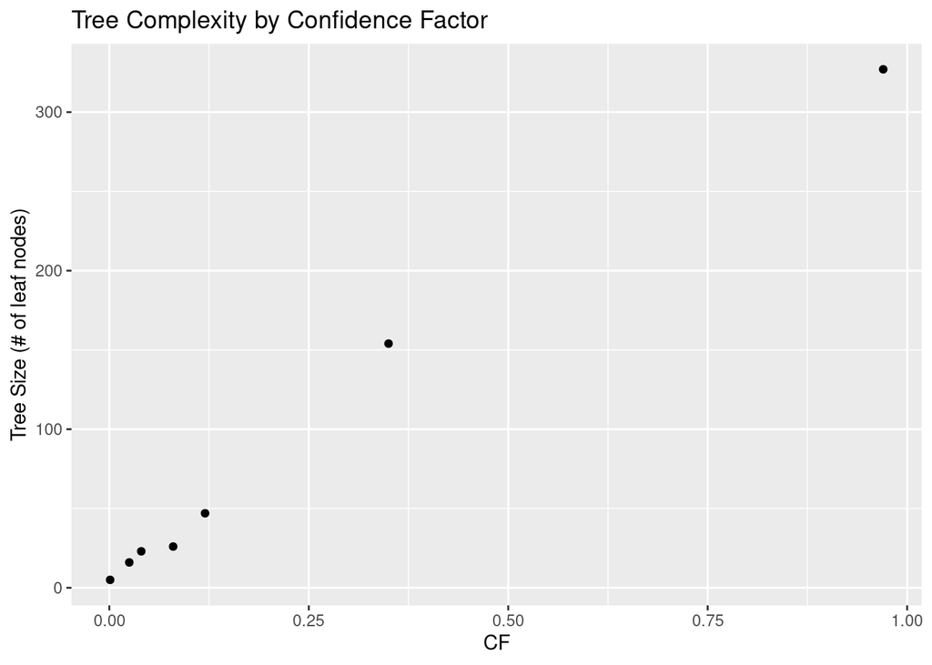

```r
cf_size_df %>%
  ggplot() +
  geom_point(aes(x = CF, y = tree_size)) +
  ylab("Tree Size (# of leaf nodes)") +
  ggtitle("Tree Complexity by Confidence Factor")
```

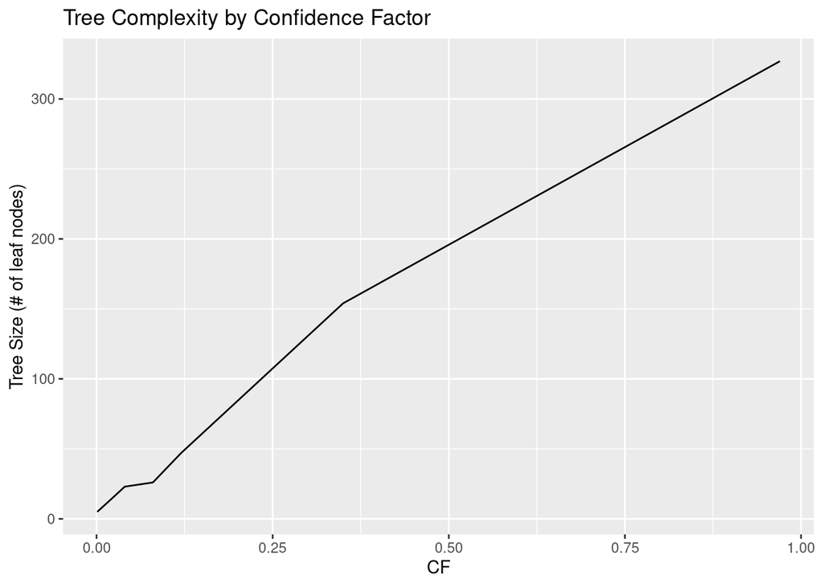

```r
cf_size_df %>%
  ggplot() +
  geom_line(aes(x = CF, y = tree_size)) +
  ylab("Tree Size (# of leaf nodes)") +
  ggtitle("Tree Complexity by Confidence Factor")
```

- The most complex tree is defined by looking at the number, which cf_1 has the largest number.
- The least complex tree is defined by looking at the number, which cf_7 has the smallest size.
- Overall: Higher the CF = more leaf nodes ; Smaller the CF = less leaf nodes

### 2.5.3 C. (1 points) Plot the least complex tree.(you may need to change the chunk figure size to fig.height=8, fig.width=20 to have an interpretable plot. use the gear icon on the chunk and “custom figure size” to do so.)

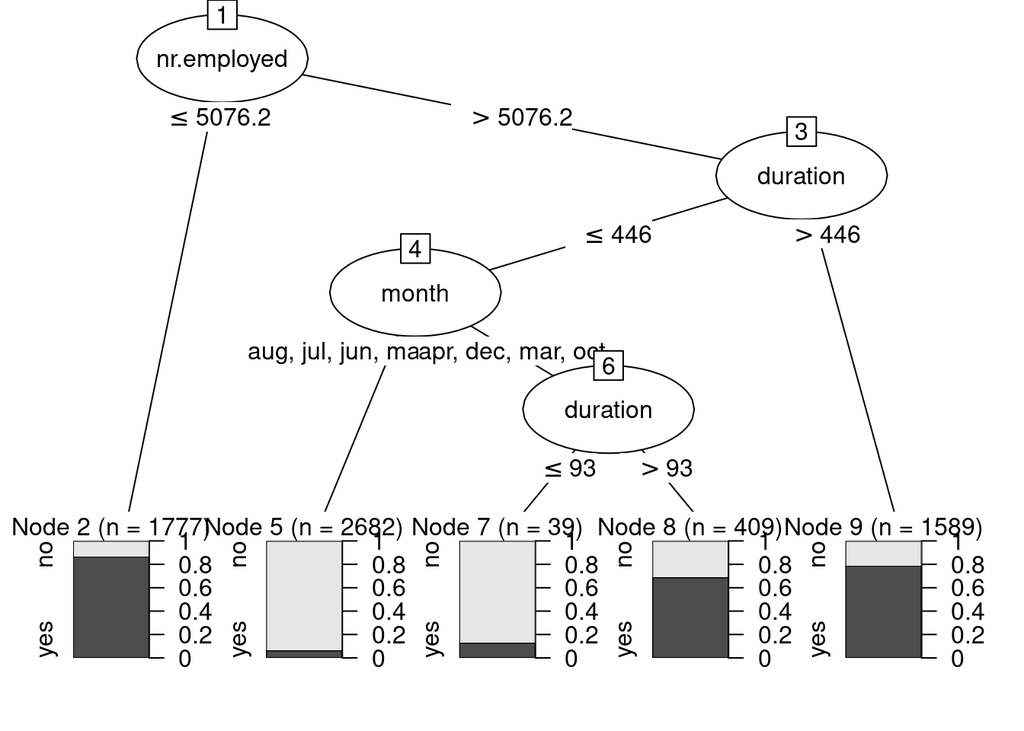

```r
plot(tree_cf_7, fig.height=8, fig.width=20)
```

### D. (3 points) Explain the steps the model would make to determine how to classify the following instance : nr.employed = 6000 and duration = 500. What would the prediction be? Consider using the least complex tree for this scenario.

The model will identify the nr.employed that is equal to 6000, which it will follow the path of ” > 5076.2 .” Then it will compare with the duration of 500, which it will follow the path ” > 446 .” The prediction will falls to leaf node 9 (n=1589).

## 2.6 Part 6 (13 points) – Predict on the Train and Test sets with each trained model.

### 2.6.1 A. (2 points) Generate predictions for all the models for both the Train set and Test set. Store each prediction vector in a local variable.

```r
#?mmetric

# Predict for Train set
tree_cf_1_train_predictions <- predict(tree_cf_1,train_set)
tree_cf_2_train_predictions <- predict(tree_cf_2,train_set)
tree_cf_3_train_predictions <- predict(tree_cf_3,train_set)
tree_cf_4_train_predictions <- predict(tree_cf_4,train_set)
tree_cf_5_train_predictions <- predict(tree_cf_5,train_set)
tree_cf_6_train_predictions <- predict(tree_cf_6,train_set)
tree_cf_7_train_predictions <- predict(tree_cf_7,train_set)
# Predict for Test set
tree_cf_1_test_predictions <- predict(tree_cf_1,test_set)
tree_cf_2_test_predictions <- predict(tree_cf_2,test_set)
tree_cf_3_test_predictions <- predict(tree_cf_3,test_set)
tree_cf_4_test_predictions <- predict(tree_cf_4,test_set)
tree_cf_5_test_predictions <- predict(tree_cf_5,test_set)
tree_cf_6_test_predictions <- predict(tree_cf_6,test_set)
tree_cf_7_test_predictions <- predict(tree_cf_7,test_set)
```

## 2.7 Part 7 (13 points) – Generate Confusion Matrices for each trained Model for both Train and Test

### 2.7.1 A. (2 points) Using the predictions create confusion matrices for all models in Train and Test

```r
# Train models
train_models <- c(
  mmetric(train_set$y, tree_cf_1_train_predictions, metric="CONF"),
  mmetric(train_set$y, tree_cf_2_train_predictions, metric="CONF"),
  mmetric(train_set$y, tree_cf_3_train_predictions, metric="CONF"),
  mmetric(train_set$y, tree_cf_4_train_predictions, metric="CONF"),
  mmetric(train_set$y, tree_cf_5_train_predictions, metric="CONF"),
  mmetric(train_set$y, tree_cf_6_train_predictions, metric="CONF"),
  mmetric(train_set$y, tree_cf_7_train_predictions, metric="CONF"))
train_models
```

```
## $res
## NULL
##
## $conf
##       pred
## target   no  yes
##    no  3005  243
##    yes  138 3110
##
## $roc
## NULL
##
## $lift
## NULL
##
## $res
## NULL
##
## $conf
##       pred
## target   no  yes
##    no  2881  367
##    yes  165 3083
##
## $roc
## NULL
##
## $lift
## NULL
##
## $res
## NULL
##
## $conf
##       pred
## target   no  yes
##    no  2736  512
##    yes  164 3084
##
## $roc
```

[output cut: 49 more lines]

```
##
## $res
## NULL
##
## $conf
##       pred
## target   no  yes
##    no  2548  700
##    yes  173 3075
##
## $roc
## NULL
##
## $lift
## NULL
```

```r
# Test models
test_models <- c(
  mmetric(test_set$y, tree_cf_1_test_predictions, metric="CONF"),
  mmetric(test_set$y, tree_cf_2_test_predictions, metric="CONF"),
  mmetric(test_set$y, tree_cf_3_test_predictions, metric="CONF"),
  mmetric(test_set$y, tree_cf_4_test_predictions, metric="CONF"),
  mmetric(test_set$y, tree_cf_5_test_predictions, metric="CONF"),
  mmetric(test_set$y, tree_cf_6_test_predictions, metric="CONF"),
  mmetric(test_set$y, tree_cf_7_test_predictions, metric="CONF"))

test_models
```

```
## $res
## NULL
##
## $conf
##       pred
## target   no  yes
##    no  1180  212
##    yes  168 1224
##
## $roc
## NULL
##
## $lift
## NULL
##
## $res
## NULL
##
## $conf
##       pred
## target   no  yes
##    no  1186  206
##    yes  124 1268
##
## $roc
## NULL
##
## $lift
## NULL
##
## $res
## NULL
##
## $conf
##       pred
## target   no  yes
##    no  1150  242
##    yes   90 1302
##
## $roc
```

[output cut: 49 more lines]

```
##
## $res
## NULL
##
## $conf
##       pred
## target   no  yes
##    no  1104  288
##    yes   73 1319
##
## $roc
## NULL
##
## $lift
## NULL
```

## 2.8 Part 8 (13 points) – Generate Evaluation Metrics for each Model

### 2.8.1 A. (2 points) Using the predictions generate Accuracy, F1, Precision, Recall score all models in Train and Test sets.

```r
# Accuracy for Train
train_acc <- c(
  mmetric(train_set$y, tree_cf_1_train_predictions, metric="ACC"),
  mmetric(train_set$y, tree_cf_2_train_predictions, metric="ACC"),
  mmetric(train_set$y, tree_cf_3_train_predictions, metric="ACC"),
  mmetric(train_set$y, tree_cf_4_train_predictions, metric="ACC"),
  mmetric(train_set$y, tree_cf_5_train_predictions, metric="ACC"),
  mmetric(train_set$y, tree_cf_6_train_predictions, metric="ACC"),
  mmetric(train_set$y, tree_cf_7_train_predictions, metric="ACC"))
train_acc
```

```
## [1] 94.13485 91.81034 89.59360 88.68534 88.43904 87.79249 86.56096
```

```r
# Accuracy for Test
test_acc <- c(
  mmetric(test_set$y, tree_cf_1_test_predictions, metric="ACC"),
  mmetric(test_set$y, tree_cf_2_test_predictions, metric="ACC"),
  mmetric(test_set$y, tree_cf_3_test_predictions, metric="ACC"),
  mmetric(test_set$y, tree_cf_4_test_predictions, metric="ACC"),
  mmetric(test_set$y, tree_cf_5_test_predictions, metric="ACC"),
  mmetric(test_set$y, tree_cf_6_test_predictions, metric="ACC"),
  mmetric(test_set$y, tree_cf_7_test_predictions, metric="ACC"))
test_acc
```

```
## [1] 86.35057 88.14655 88.07471 88.11063 88.14655 87.60776 87.03305
```

#### 2.8.1.2 F1

```r
# F1 for Train
train_f1 <- c(
  mmetric(train_set$y, tree_cf_1_train_predictions, metric="F1"),
  mmetric(train_set$y, tree_cf_2_train_predictions, metric="F1"),
  mmetric(train_set$y, tree_cf_3_train_predictions, metric="F1"),
  mmetric(train_set$y, tree_cf_4_train_predictions, metric="F1"),
  mmetric(train_set$y, tree_cf_5_train_predictions, metric="F1"),
  mmetric(train_set$y, tree_cf_6_train_predictions, metric="F1"),
  mmetric(train_set$y, tree_cf_7_train_predictions, metric="F1"))
train_f1
```

```
##  [1] 94.03849 94.22815 91.54751 92.05733 89.00455 90.12274 88.15089 89.17366
##  [9] 87.82623 88.99311 87.01065 88.48555 85.37443 87.56941
```

```r
# F1 for Test
test_f1 <- c(
  mmetric(test_set$y, tree_cf_1_test_predictions, metric="F1"),
  mmetric(test_set$y, tree_cf_2_test_predictions, metric="F1"),
  mmetric(test_set$y, tree_cf_3_test_predictions, metric="F1"),
  mmetric(test_set$y, tree_cf_4_test_predictions, metric="F1"),
  mmetric(test_set$y, tree_cf_5_test_predictions, metric="F1"),
  mmetric(test_set$y, tree_cf_6_test_predictions, metric="F1"),
  mmetric(test_set$y, tree_cf_7_test_predictions, metric="F1"))
test_f1
```

```
##  [1] 86.13139 86.56294 87.78682 88.48569 87.38602 88.69210 87.59835 88.58227
##  [9] 87.57530 88.66758 86.78667 88.33277 85.94784 87.96265
```

#### 2.8.1.3 Precision

```r
# Precision for Train
train_precision <- c(
  mmetric(train_set$y, tree_cf_1_train_predictions, metric="PRECISION"),
  mmetric(train_set$y, tree_cf_2_train_predictions, metric="PRECISION"),
  mmetric(train_set$y, tree_cf_3_train_predictions, metric="PRECISION"),
  mmetric(train_set$y, tree_cf_4_train_predictions, metric="PRECISION"),
  mmetric(train_set$y, tree_cf_5_train_predictions, metric="PRECISION"),
  mmetric(train_set$y, tree_cf_6_train_predictions, metric="PRECISION"),
  mmetric(train_set$y, tree_cf_7_train_predictions, metric="PRECISION"))
train_precision
```

```
##  [1] 95.60929 92.75276 94.58306 89.36232 94.34483 85.76196 92.52115 85.48433
##  [9] 92.74221 84.92308 92.96465 83.73179 93.64204 81.45695
```

```r
# Precision for Test
test_precision <- c(
  mmetric(test_set$y, tree_cf_1_test_predictions, metric="PRECISION"),
  mmetric(test_set$y, tree_cf_2_test_predictions, metric="PRECISION"),
  mmetric(test_set$y, tree_cf_3_test_predictions, metric="PRECISION"),
  mmetric(test_set$y, tree_cf_4_test_predictions, metric="PRECISION"),
  mmetric(test_set$y, tree_cf_5_test_predictions, metric="PRECISION"),
  mmetric(test_set$y, tree_cf_6_test_predictions, metric="PRECISION"),
  mmetric(test_set$y, tree_cf_7_test_predictions, metric="PRECISION"))
test_precision
```

```
##  [1] 87.53709 85.23677 90.53435 86.02442 92.74194 84.32642 91.54268 85.20239
##  [9] 92.00949 84.93421 92.94504 83.45048 93.79779 82.07841
```

```r
# Recall for Train
train_recall <- c(
  mmetric(train_set$y, tree_cf_1_train_predictions, metric="TPR"),
  mmetric(train_set$y, tree_cf_2_train_predictions, metric="TPR"),
  mmetric(train_set$y, tree_cf_3_train_predictions, metric="TPR"),
  mmetric(train_set$y, tree_cf_4_train_predictions, metric="TPR"),
  mmetric(train_set$y, tree_cf_5_train_predictions, metric="TPR"),
  mmetric(train_set$y, tree_cf_6_train_predictions, metric="TPR"),
  mmetric(train_set$y, tree_cf_7_train_predictions, metric="TPR"))
train_recall
```

```
##  [1] 92.51847 95.75123 88.70074 94.91995 84.23645 94.95074 84.17488 93.19581
##  [9] 83.40517 93.47291 81.77340 93.81158 78.44828 94.67365
```

```r
# Recall for Test
test_recall <- c(
  mmetric(test_set$y, tree_cf_1_test_predictions, metric="TPR"),
  mmetric(test_set$y, tree_cf_2_test_predictions, metric="TPR"),
  mmetric(test_set$y, tree_cf_3_test_predictions, metric="TPR"),
  mmetric(test_set$y, tree_cf_4_test_predictions, metric="TPR"),
  mmetric(test_set$y, tree_cf_5_test_predictions, metric="TPR"),
  mmetric(test_set$y, tree_cf_6_test_predictions, metric="TPR"),
  mmetric(test_set$y, tree_cf_7_test_predictions, metric="TPR"))
test_recall
```

```
##  [1] 84.77011 87.93103 85.20115 91.09195 82.61494 93.53448 83.97989 92.24138
##  [9] 83.54885 92.74425 81.39368 93.82184 79.31034 94.75575
```

### 2.8.2 B. Optional: You might consider create a dataframe of the results as shown in Titanic C50 tutorial

```r
# Accuracy
acc_df_cf <- data.frame(train_acc,test_acc,cf_vector,leaf_nodes_vector)
acc_df_cf
```

```
##   train_acc test_acc cf_vector leaf_nodes_vector
## 1  94.13485 86.35057     0.970               327
## 2  91.81034 88.14655     0.350               154
## 3  89.59360 88.07471     0.120                47
## 4  88.68534 88.11063     0.080                26
## 5  88.43904 88.14655     0.040                23
## 6  87.79249 87.60776     0.025                16
## 7  86.56096 87.03305     0.001                 5
```

```r
# F1
f1_df_cf <- data.frame(train_f1,test_f1,cf_vector,leaf_nodes_vector)
f1_df_cf
```

```
##    train_f1  test_f1 cf_vector leaf_nodes_vector
## 1  94.03849 86.13139     0.970               327
## 2  94.22815 86.56294     0.350               154
## 3  91.54751 87.78682     0.120                47
## 4  92.05733 88.48569     0.080                26
## 5  89.00455 87.38602     0.040                23
## 6  90.12274 88.69210     0.025                16
## 7  88.15089 87.59835     0.001                 5
## 8  89.17366 88.58227     0.970               327
## 9  87.82623 87.57530     0.350               154
## 10 88.99311 88.66758     0.120                47
## 11 87.01065 86.78667     0.080                26
## 12 88.48555 88.33277     0.040                23
## 13 85.37443 85.94784     0.025                16
## 14 87.56941 87.96265     0.001                 5
```

```r
# Precsision
precision_df_cf <- data.frame(train_precision,test_precision,cf_vector,leaf_nodes_vector)
precision_df_cf
```

```
##    train_precision test_precision cf_vector leaf_nodes_vector
## 1         95.60929       87.53709     0.970               327
## 2         92.75276       85.23677     0.350               154
## 3         94.58306       90.53435     0.120                47
## 4         89.36232       86.02442     0.080                26
## 5         94.34483       92.74194     0.040                23
## 6         85.76196       84.32642     0.025                16
## 7         92.52115       91.54268     0.001                 5
## 8         85.48433       85.20239     0.970               327
## 9         92.74221       92.00949     0.350               154
## 10        84.92308       84.93421     0.120                47
## 11        92.96465       92.94504     0.080                26
## 12        83.73179       83.45048     0.040                23
## 13        93.64204       93.79779     0.025                16
## 14        81.45695       82.07841     0.001                 5
```

```r
# Recall
recall_df_cf <- data.frame(train_recall,test_recall,cf_vector,leaf_nodes_vector)
recall_df_cf
```

```
##    train_recall test_recall cf_vector leaf_nodes_vector
## 1      92.51847    84.77011     0.970               327
## 2      95.75123    87.93103     0.350               154
## 3      88.70074    85.20115     0.120                47
## 4      94.91995    91.09195     0.080                26
## 5      84.23645    82.61494     0.040                23
## 6      94.95074    93.53448     0.025                16
## 7      84.17488    83.97989     0.001                 5
## 8      93.19581    92.24138     0.970               327
## 9      83.40517    83.54885     0.350               154
## 10     93.47291    92.74425     0.120                47
## 11     81.77340    81.39368     0.080                26
## 12     93.81158    93.82184     0.040                23
## 13     78.44828    79.31034     0.025                16
## 14     94.67365    94.75575     0.001                 5
```

## 2.9 Part 9 (3 points) – Show the feature importance for each Model

### 2.9.1 A. (1 point) As shown in Titanic Tutorial show the feature importance for each of the Decision Trees.

```r
C5imp(tree_cf_1)
```

```
##                Overall
## duration        100.00
## nr.employed     100.00
## month            69.81
## poutcome         62.19
## contact          40.35
## job              35.27
## emp.var.rate     33.84
## euribor3m        27.96
## day_of_week       8.96
## default           8.94
## cons.conf.idx     8.87
## education         8.81
## loan              7.56
## pdays             6.59
## cons.price.idx    6.00
## campaign          4.77
## marital           3.93
## housing           2.86
## age               2.59
## previous          0.79
```

```r
C5imp(tree_cf_2)
```

```
##                Overall
## duration        100.00
## nr.employed     100.00
## month            56.76
## poutcome         41.55
## emp.var.rate     32.20
## euribor3m        27.77
## contact          16.52
## cons.conf.idx     8.65
## job               7.53
## day_of_week       6.74
## pdays             6.59
## default           6.30
## loan              6.27
## cons.price.idx    5.93
## age               2.16
## housing           1.94
## education         1.20
## marital           1.15
## campaign          1.02
## previous          0.52
```

```r
C5imp(tree_cf_3)
```

```
##                Overall
## duration        100.00
## nr.employed     100.00
## month            50.35
## emp.var.rate     43.60
## poutcome         41.29
## contact          16.19
## euribor3m        14.25
## cons.conf.idx     8.65
## default           6.30
## cons.price.idx    5.93
## day_of_week       5.56
## pdays             4.54
## loan              2.69
## age               1.68
## job               1.08
## education         0.58
## marital           0.29
## previous          0.18
## housing           0.00
## campaign          0.00
```

```r
C5imp(tree_cf_4)
```

```
##                Overall
## duration        100.00
## nr.employed     100.00
## month            48.18
## poutcome         41.29
## contact          13.49
## cons.conf.idx     8.65
## default           6.30
## cons.price.idx    5.93
## day_of_week       5.56
## pdays             4.22
## loan              2.69
## emp.var.rate      2.63
## age               1.62
## euribor3m         1.52
## job               1.08
## marital           0.00
## education         0.00
## housing           0.00
## campaign          0.00
## previous          0.00
```

```r
C5imp(tree_cf_5)
```

```
##                Overall
## duration        100.00
## nr.employed     100.00
## month            48.18
## poutcome         41.29
## contact          13.49
## default           6.30
## cons.price.idx    5.93
## day_of_week       5.56
## cons.conf.idx     5.56
## emp.var.rate      2.63
## age               1.62
## euribor3m         1.52
## job               1.08
## marital           0.00
## education         0.00
## housing           0.00
## loan              0.00
## campaign          0.00
## pdays             0.00
## previous          0.00
```

```r
C5imp(tree_cf_6)
```

```
##                Overall
## nr.employed     100.00
## duration         72.64
## month            48.18
## poutcome         41.29
## contact           8.85
## cons.price.idx    6.30
## cons.conf.idx     5.93
## day_of_week       4.66
## emp.var.rate      2.63
## euribor3m         1.69
## age               1.59
## job               0.00
## marital           0.00
## education         0.00
## default           0.00
## housing           0.00
## loan              0.00
## campaign          0.00
## pdays             0.00
## previous          0.00
```

```r
C5imp(tree_cf_7)
```

```
##                Overall
## nr.employed     100.00
## duration         72.64
## month            48.18
## age               0.00
## job               0.00
## marital           0.00
## education         0.00
## default           0.00
## housing           0.00
## loan              0.00
## contact           0.00
## day_of_week       0.00
## campaign          0.00
## pdays             0.00
## previous          0.00
## poutcome          0.00
## emp.var.rate      0.00
## cons.price.idx    0.00
## cons.conf.idx     0.00
## euribor3m         0.00
```

### 2.9.2 B. What were the top 4 features in a majority of the models?

NR.EMPLOYED, DURATION, MONTH, POUTCOME are 4 features in a majority of the models

## 2.10 Part 10 (OPTIONAL) – Generate a Graph showing Train and Test Accuracy for each model. As shown in Titanic Tutorial.

[figure not shown]

```r
# This graph is quite complex, no need to change anything here. Just run as is.

ggplot() +
  geom_line(aes(x=acc_df_cf$leaf_nodes_vector,y=acc_df_cf$train_acc,color='Train Accuracy')) +
  geom_line(aes(x=acc_df_cf$leaf_nodes_vector,y=acc_df_cf$test_acc,color='Test Accuracy')) +
  scale_color_manual(values = c("Train Accuracy" = "red", "Test Accuracy" = "blue")) +
  ggtitle("Titanic Tree Accuracy in Test and Train by number of leaf nodes.") +
  xlab('Tree Complexity (Leaf Nodes)') +
  ylab('Accuracy') +
  ylim(75,100) +
  geom_point(aes(x=7,y=82.8)) +
  geom_point(aes(x=12,y=83.15)) +
  geom_vline(xintercept = 7) +
  geom_text(aes(x=4,y=93),label='<- Underfitted') +
  geom_text(aes(x=12,y=93),label='Increasingly Overfitted ->')
```

# 3 Task II: Reflections (13%)

The Confidence Factor (CF) is used to control the trade-off between model complexity and the risk of overfitting. It sets a threshold for the statistical significance of splits during the pruning process:

High CF Values (e.g., close to 0.99):

Less Pruning: Higher CF values make the pruning process less aggressive. More Complex Model: The decision tree is allowed to grow larger, with more branches and leaf nodes. This results in a more complex model that captures more details of the training data. Risk of Overfitting: The model may overfit the training data, capturing noise and specific patterns that may not generalize well to unseen data. Low CF Values (e.g., close to 0.001):

More Pruning: Lower CF values make the pruning process more aggressive. Simpler Model: The decision tree is pruned more, resulting in a smaller tree with fewer branches and leaf nodes. This results in a simpler model. Reduced Overfitting: The model is less likely to overfit the training data and may generalize better to new data, but it may also miss some finer details of the training data. How CF Affects Model Complexity Number of Nodes and Depth:

High CF: The tree will have more nodes and greater depth, as fewer branches are pruned away. Low CF: The tree will have fewer nodes and shallower depth, as more branches are pruned. Decision Boundaries:

High CF: The decision boundaries are more complex, potentially capturing intricate patterns in the data. Low CF: The decision boundaries are simpler, potentially capturing more general patterns. Leaf Nodes:

High CF: More leaf nodes, each representing a more specific subset of the data. Low CF: Fewer leaf nodes, each representing a larger subset of the data.

## 3.4 5. Which of the decision tree models is most complex? (Based your answer on the count of Leaf Nodes)

Base on Part 5B mention about explanation of the most and least complex: - The most complex tree is defined by looking at the number, which cf_1 has the largest number. - The least complex tree is defined by looking at the number, which cf_7 has the smallest size. - Overall: Higher the CF = more leaf nodes ; Smaller the CF = less leaf nodes

## 3.6 7. Which two of the decision tree models underfit the training and testing data? (Answer the question based on the overall decision tree accuracy/errors)

I believe the model 7 has the underfit of the training and testing data. since the CF value is nearly 0, it leads to the lack of values (too simple) to create a strong accuracy and errors.

## 3.7 8. Explain your reasons for choosing the decision trees. (Provide quantitative answers)

When choosing decision tree models, several quantitative factors should be considered to justify their selection. Decision trees have distinct advantages, including interpretability, the ability to handle both numerical and categorical data, and minimal preprocessing requirements. Below are the key quantitative reasons for choosing decision tree models:

1. Performance Metrics

Decision trees might have been chosen based on their performance metrics on the training and validation datasets. Here are potential metrics:

Accuracy: The proportion of correctly classified instances out of the total instances. High accuracy indicates good performance. Precision, Recall, and F1 Score: Metrics that are particularly useful in imbalanced datasets to evaluate the quality of positive predictions. Error Rates: Low error rates on both training and validation datasets indicate good model performance.

2. Interpretability

Feature Importance: Decision trees provide insight into which features are most important for prediction. Quantitatively, this can be measured by the importance score assigned to each feature by the model. Model Transparency: The structure of the tree (e.g., depth, number of nodes) is intuitive and easy to visualize, making the model’s decision process transparent.

3. Complexity and Overfitting

Model Complexity: Decision trees can be pruned to control complexity. A balance between tree depth and performance metrics ensures that the model is not overfitting. Overfitting Measures: Cross-validation scores help in assessing whether the model generalizes well to unseen data. A small difference between training and validation scores indicates minimal overfitting.

4. Handling of Data Types

Numerical and Categorical Data: Decision trees natively handle both types of data without the need for extensive preprocessing. Missing Values: Some implementations of decision trees can handle missing values, thus preserving data integrity.

5. Speed and Scalability

Training Speed: Decision trees are generally faster to train compared to more complex models like neural networks. Prediction Speed: Once trained, decision trees make predictions quickly, which is beneficial for real-time applications.

## 3.9 Additional questions:

### 3.9.1 1. What was the relationship between complexity and the time required to generate a model? Are there any potential issues that may arise with a high runtime?

### 3.9.2 2. What metrics did you use to decide which model had the best performance? Why those? Did some metrics have more weight than others?